# Longitudinal analysis of economic news using Quanteda

6 June 2018

## What is Quanteda?

## Quanteda is an R package

**quanteda** is an R package for quantitative text analysis developed by a team based at the LSE.

- **quanteda** stands for **qu**antetative **an**alysis of **te**xtual **da**ta
- The package offers a set of functions for quantitative text analysis
  - See https://docs.quanteda.io/reference for the list of functions
- Developed for high *consistency* and *performance*
  - Many of the core functions are written in C++ with multi-threading
  - Faster than other R packages (**tm** or **tidytext**) and even Python package (**gensim**)
  - Works with Chinese, Japanese and Korean texts
- Used by leading political scientists in North America, Europe and Asia
  - Analyze party manifestos, legislative speeches, news articles, social media etc.

## Quanteda team

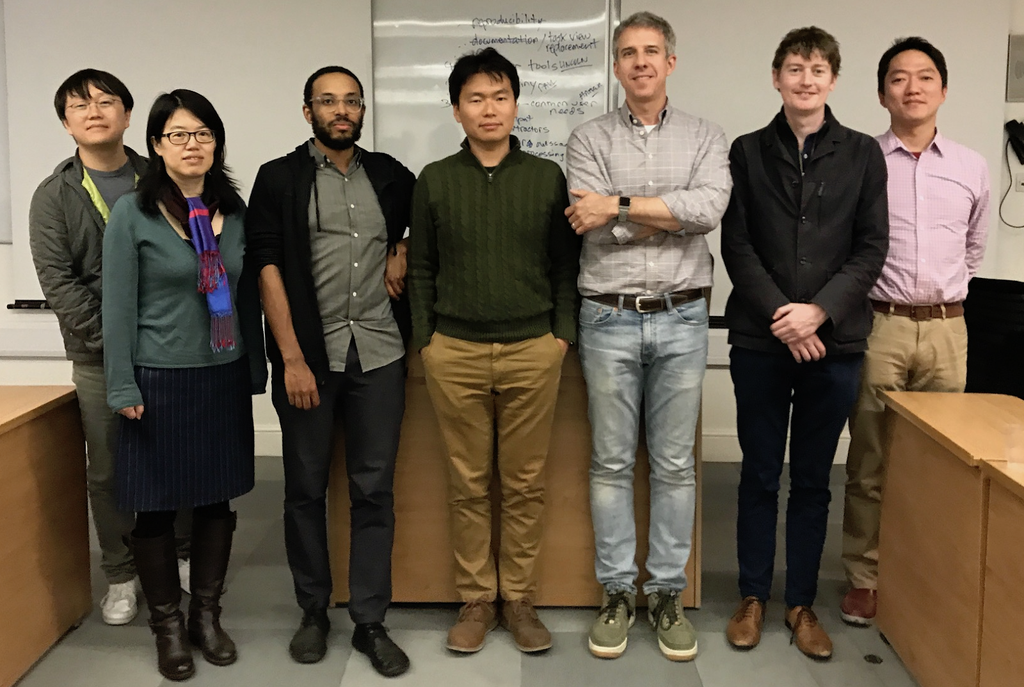

## What is quantitative text analysis

In quantitative text analysis, we use the same technologies as natural language processing (NLP) but for different goals.

- We try to discover *theoretically interesting* patterns from a social scientific point of view
  - Replication of manual reading of text is not the goal
  - Social scientists are interested in specific aspects of textual data
- Analytic methods vary from simple frequency analysis to machine learning
  - Dictionary analysis is probably the most popular approach
  - Machine learning is becoming more popular these days

## Cost-control trade off in machine learning

Not easy to automate theoretically grounded analysis because of the cost-control trade off.

- Complex models require a lot of data to learn
- Supervised models can be theoretical but usually expensive
  - naive Bayes, Wordscores, random forest, SVM, neural network
- Unsupervised models are inexpensive but often atheoretical
  - topic models, correspondence analysis, Wordfish
- Semi-supervised models try to balance between theory and cost
  - Newsmap, LSS

## Examples

## Sentiment analysis of news

- Lexicoder Sentiment Dictionary (LSD)
  - Widely used in political communication research
  - Created by Young and Soroka to analyze political news in North America

  ```r
  lengths(data_dictionary_LSD2015)
  ```

  ```
  ##     negative     positive neg_positive neg_negative
  ##         2858         1709         1721         2860
  ```

- Latent Semantic Scaling (LSS)
  - Parameters are estimated on the corpus to increase internal validity
  - Uses "seed words" to identify subject-specific sentiment words

## Lexicoder Sentiment Dictionary

```r
corp <- readRDS('/home/kohei/Dropbox/Public/data_corpus_guardian2016-10k.rds')
ndoc(corp)
```

```
## [1] 10000
```

```r
range(docvars(corp, "date"))
```

```
## [1] "2016-01-01" "2016-12-31"
```

```r
mt <- dfm(corp, remove_punc = TRUE, remove = stopwords())
mt_dict <- dfm_lookup(mt, data_dictionary_LSD2015[1:2])
sent <- (mt_dict[,2] - mt_dict[,1]) / (rowSums(mt) + 1)

data <- data.frame(date = docvars(mt_dict, "date"),
                   lsd = as.numeric(scale(sent)))
```

```r
dim(mt)
```

```
## [1]  10000 121885
```

```r
head(mt[1:6, 1:6])
```

```
## Document-feature matrix of: 6 documents, 6 features (80.6% sparse).
## 6 x 6 sparse Matrix of class "dfm"
##             features
## docs         70-year-old hermit spent entire life siberian
##   text120761           1      1     1      1    2        1
##   text174574           0      0     0      0    0        0
##   text141269           0      0     0      0    0        0
##   text151432           0      0     0      0    0        0
##   text169265           0      0     0      0    0        0
##   text134827           0      0     0      0    1        0
```

```r
dim(mt_dict)
```

```
## [1] 10000     2
```

```r
head(mt_dict)
```

```
## Document-feature matrix of: 6 documents, 2 features (0% sparse).
## 6 x 2 sparse Matrix of class "dfm"
##             features
## docs         negative positive
##   text120761       11        6
##   text174574       17       16
##   text141269       20       38
##   text151432       15       27
##   text169265       24       27
##   text134827       66       50
```

## Sentiment of news around Brexit vote by LSD

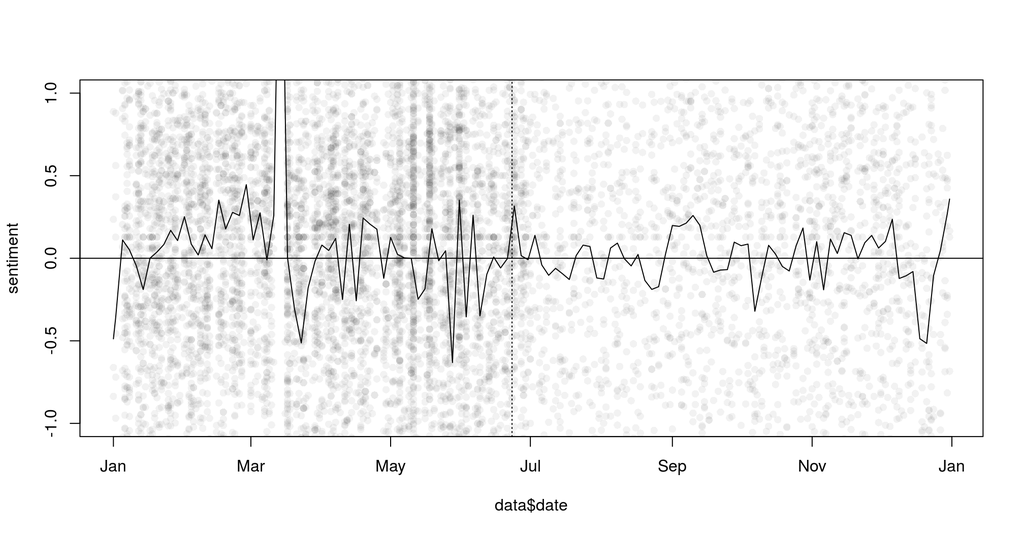

## Latent Semantic Scaling

```r
devtools::install_github("koheiw/LSS")
```

```r
require(LSS)
toks_sent <- corp %>%
    corpus_reshape('sentences') %>%
    tokens(remove_punct = TRUE)
mt_sent <- toks_sent %>%
    dfm(remove = stopwords()) %>%
    dfm_select('^[0-9a-zA-Z]+$', valuetype = 'regex') %>%
    dfm_trim(min_termfreq = 5)

eco <- head(char_keyness(toks_sent, 'econom*', window = 10), 500)
lss <- textmodel_lss(mt_sent, seedwords('pos-neg'), features = eco, cache = TRUE)
```

## Sentiment seed words

```r
seedwords('pos-neg')
```

```
##        good        nice   excellent    positive   fortunate     correct
##           1           1           1           1           1           1
##    superior         bad       nasty        poor    negative unfortunate
##           1          -1          -1          -1          -1          -1
##       wrong    inferior
##          -1          -1
```

## Economic sentiment words

```r
head(coef(lss), 20) # most positive words
```

```
##    positive    emerging       china   expecting cooperation        drag
##  0.03941849  0.03906230  0.03249657  0.03172653  0.03014628  0.02910002
##        asia        prof sustainable    academic challenging     markets
##  0.02873776  0.02849241  0.02765765  0.02732935  0.02682587  0.02644153
##   investors   prospects       stock      better   uncertain   strategic
##  0.02637175  0.02570061  0.02538831  0.02479903  0.02358457  0.02346433
##         hit     chinese
##  0.02302436  0.02291012
```

```r
tail(coef(lss), 20) # most negative words
```

```
##     downturn       macron     suggests     downbeat         debt
##  -0.03257441  -0.03258820  -0.03277442  -0.03309793  -0.03386571
##         data policymakers   unbalanced       shrink unemployment
##  -0.03524238  -0.03745570  -0.03934074  -0.03944345  -0.03987688
##    suggested          bad     pantheon      cutting       shocks
##  -0.04036920  -0.04047418  -0.04054125  -0.04082423  -0.04267978
##        rates          rba         rate          cut     negative
##  -0.04405703  -0.04789902  -0.05417844  -0.05498620  -0.05697134
```

## Sentiment of news around Brexit vote by LSS

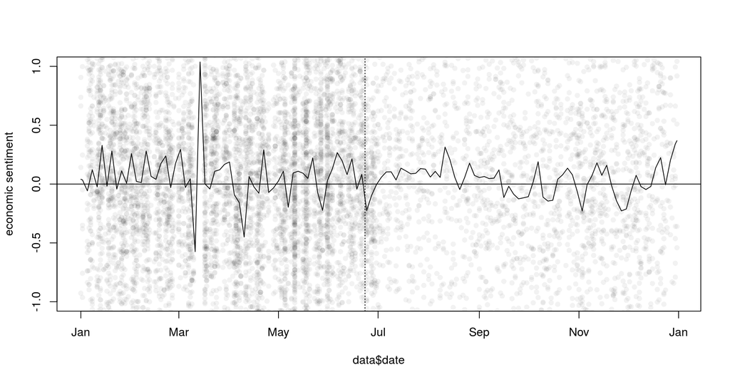

## Compare LSD and LSS

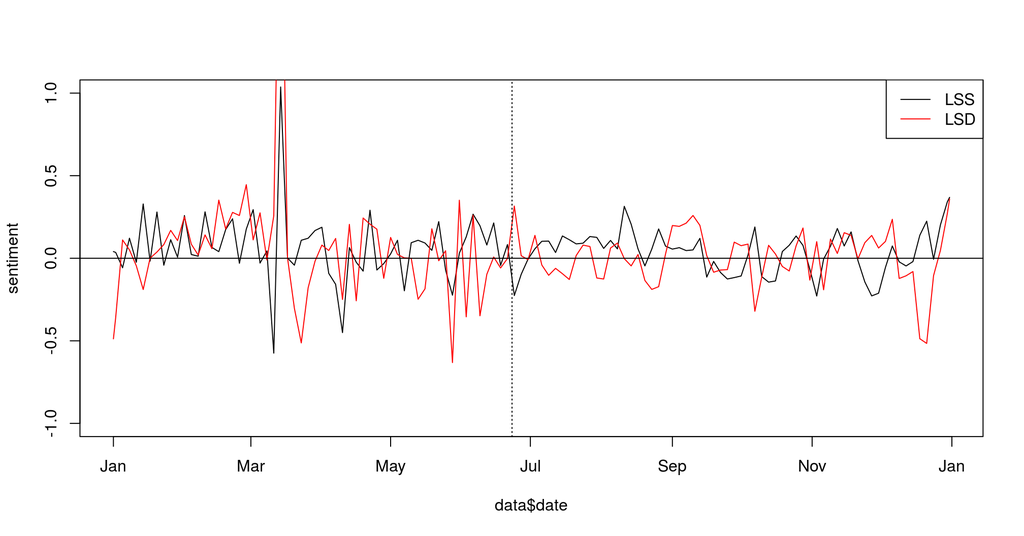

## Seed words for different dimensions

The sentiment seed words are already available, but you can also make you own seed words.

```r
# concern
seed_concern <- c("concern*", "worr*", "anxi*")

# weakening
seed_weakening <- c("declin*", "weak*", "retreat*")

# indicator vs consequence
seed_ecoframe <- c('рост*' = 1, 'инфляци*' = 1, 'безработиц*' = 1,
                 # 'growth'     'inflation'   'unemployment'
                   'рубл*' = 1, 'бедност*' = -1, 'сокращени* доходов' = -1,
                 # 'currency'  'poverty'        'wage reduction'
                   'забастовк*' = -1, 'увольнени* работник*' = 1, 'потер*' = -1)
                 # 'strikes'          'layoff'                    'economic loss'
```

## Conclusions

You can locate documents on sentiment or any other dimensions at low cost using LSS.

- It is an ideal tool to generate time series data from news articles
- It can be used in economic research along with macro-economic data

When you use LSS, please be aware that

- It requires large corpus of texts (usually 5000 or more full-text articles)
- It is affected by how texts are tokenized (punctuations, function words etc.)
- Its individual prediction is not very accurate (compared to full-supervised models)

## More about Quanteda

- Quanteda Documentation: https://docs.quanteda.io
- Quanteda Tutorials: https://tutorials.quanteda.io
  - Overview
  - Data import
  - Basic operations
  - Statistical analysis
  - Advanced operations
  - Scaling and classification
- These slides: https://github.com/koheiw/workshop-BEAM
- There might be introductory text analysis workshop using Quanteda at Waseda